# Chapter 18: Comparing Two Means

The Practice of Statistics in the Life Sciences by Brigitte Baldi and David S. Moore

Instructor: Ali Raisolsadat

Part IV: Specific Inference Procedures

# 18 Chapter 18

## 18.1 From One Population Mean to Two

Chapter 17 developed confidence intervals and hypothesis tests for one population mean and for the mean of paired differences. Chapter 18 considers a different structure: two separate samples of unrelated individuals.

The main parameter is

$$\mu_1-\mu_2$$

where $\mu_1$ and $\mu_2$ are the population means for Groups $1$ and $2$. The natural estimate is

$$\bar{x}_1-\bar{x}_2$$

> **Main transition**

> A one-sample procedure measures uncertainty in one sample mean. A two-sample procedure must combine uncertainty from two independent sample means.

### 18.1.1 Learning Goals

After studying this chapter, you should be able to

1. distinguish independent two-sample data from matched pairs;
2. identify the response variable, grouping variable and parameter;
3. assess the design, independence and distributional conditions;
4. calculate the standard error of a difference in sample means;
5. construct and interpret a Welch two-sample $t$ confidence interval;
6. perform and interpret one-sided and two-sided Welch $t$ tests;
7. reproduce the calculations using R;
8. assess robustness to skewness and outliers;
9. explain why the pooled procedure is generally avoided; and
10. separate statistical evidence, effect size, generalization and causation.

## 18.2 Recognizing a Two-Sample Problem

A **two-sample problem** compares a quantitative response across two distinct groups. The groups may represent different populations or different treatments.

A two-sample problem has the following structure:

- one sample is available for each group;
- the same quantitative response is measured in both groups;
- the observations in one sample are unrelated to the observations in the other;
- the sample sizes may differ; and
- the goal is to compare population means.

### 18.2.1 Common Study Designs

| Design | How the groups arise | Main inferential strength |
| --- | --- | --- |
| Randomized comparative experiment | Experimental units are randomly assigned to two treatments | Supports a causal comparison of treatments |
| Two separate random samples | One random sample is selected from each population | Supports generalization to both sampled populations |
| Subgroups within one random sample | One sample is divided using a pre-existing characteristic | Supports population comparison but generally not causation |
| Two convenience samples | Participants enter each group without random sampling or assignment | Usually supports only a cautious description or association |

The formulas do not determine the scope of a conclusion. The study design does.

### 18.2.2 Independent Samples versus Matched Pairs

| Feature | Independent samples | Matched pairs |
| --- | --- | --- |
| Observational units | Different, unrelated individuals | Same individual twice or deliberately matched units |
| Statistic | $\bar{x}_1-\bar{x}_2$ | Mean of the paired differences, $\bar{d}$ |
| Standard error | Combines two sample variances | Uses the standard deviation of one sample of differences |
| Procedure | Welch two-sample $t$ | One-sample $t$ applied to differences |
| Example | Separate treatment and control animals | Measurements before and after treatment on each animal |

Repeated measurements on the same individuals are not independent. They should not be analyzed using a two-sample procedure.

### 18.2.3 Quantitative Response and Two-Level Factor

A two-sample problem can be viewed as a bivariate problem:

- the **response variable** is quantitative; and
- the **explanatory variable** is categorical with two levels.

For example, when comparing hatching weights for transgenic and commercial chickens, hatching weight is the quantitative response and chicken type is the two-level factor.

## 18.3 Describe the Two Samples First

Inference should begin with data analysis.

For small samples, use dotplots. For larger samples, use boxplots or histograms. Compare

- the centres;
- the spreads;
- the shapes;
- the presence of clusters or gaps;
- possible outliers; and
- whether one mean is scientifically meaningful for each distribution.

A test statistic cannot reveal subgroup structure or an influential outlier.

## 18.4 Conditions for Comparing Two Means

Welch two-sample $t$ procedures rely on the following conditions.

### 18.4.1 Random Sampling or Random Assignment

Each sample should represent its population or treatment group through a defensible random process.

Random sampling supports generalization to a population. Random assignment supports causal comparison of treatments. A convenience sample may still be analyzed descriptively, but the population conclusion must be limited.

### 18.4.2 Independence within Each Sample

Observations within a sample should not determine one another.

When sampling without replacement, each population should be much larger than its sample. A common guideline is

$$n_1\leq0.10N_1
\qquad\text{and}\qquad
n_2\leq0.10N_2$$

### 18.4.3 Independence between the Samples

The two samples must contain unrelated observations. Matching violates this condition.

For example, measurements from the left and right eye of the same animal are related. A matched analysis is required.

### 18.4.4 Distributional Condition

The procedure is exact under Normal population models and is approximately reliable for many non-Normal populations when the samples are sufficiently large.

The following issues require attention:

- strong skewness in either group;
- one or more outliers;
- a very small sample in one group; and
- important subgroups or multimodality.

Equal population variances are **not** required for Welch’s procedure.

## 18.5 Population and Sample Notation

### 18.5.1 Population Quantities

| Population | Variable | Mean | Standard deviation |
| --- | --- | --- | --- |
| Group $1$ | $X_1$ | $\mu_1$ | $\sigma_1$ |
| Group $2$ | $X_2$ | $\mu_2$ | $\sigma_2$ |

The parameter of interest is usually

$$\mu_1-\mu_2$$

### 18.5.2 Sample Quantities

| Sample | Size | Mean | Standard deviation |
| --- | --- | --- | --- |
| Group $1$ | $n_1$ | $\bar{x}_1$ | $s_1$ |
| Group $2$ | $n_2$ | $\bar{x}_2$ | $s_2$ |

The point estimate is

$$\bar{x}_1-\bar{x}_2$$

### 18.5.3 The Order of Subtraction

The group order must remain consistent.

If Group $1$ is treatment and Group $2$ is control, then $\bar{x}_1-\bar{x}_2$ estimates the treatment mean minus the control mean.

A positive value means Group $1$ has the larger sample mean. Reversing the labels changes the sign of the estimate, interval and test statistic, but it does not change the strength of a two-sided test.

## 18.6 Sampling Distribution of a Difference in Means

### 18.6.1 Centre

Because the sample means are unbiased,

$$E(\bar{X}_1-\bar{X}_2)=\mu_1-\mu_2$$

The difference in sample means is an unbiased estimator of the difference in population means.

### 18.6.2 Why the Variances Add

For independent random variables,

$$\operatorname{Var}(\bar{X}_1-\bar{X}_2)
=
\operatorname{Var}(\bar{X}_1)
+
\operatorname{Var}(\bar{X}_2)$$

Thus,

$$\operatorname{Var}(\bar{X}_1-\bar{X}_2)
=
\frac{\sigma_1^2}{n_1}
+
\frac{\sigma_2^2}{n_2}$$

The variances add even though the means are subtracted. Both independent sources of uncertainty contribute to the difference.

### 18.6.3 Population Standard Deviation

$$\sigma_{\bar{X}_1-\bar{X}_2}
=
\sqrt{
\frac{\sigma_1^2}{n_1}
+
\frac{\sigma_2^2}{n_2}
}$$

### 18.6.4 Estimated Standard Error

Because $\sigma_1$ and $\sigma_2$ are unknown,

$$\operatorname{SE}(\bar{x}_1-\bar{x}_2)
=
\sqrt{
\frac{s_1^2}{n_1}
+
\frac{s_2^2}{n_2}
}$$

Larger sample sizes reduce the standard error. Greater within-group variation increases it.

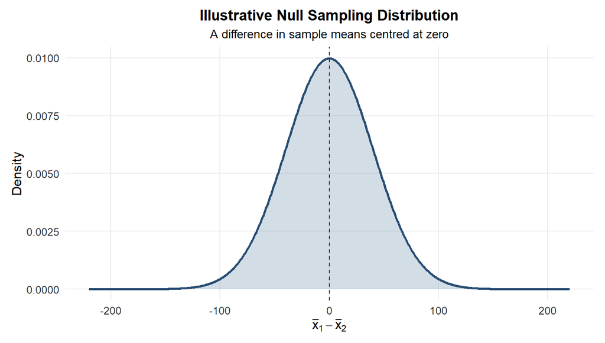

## 18.7 The Welch Two-Sample $t$ Statistic

To compare the observed difference with a hypothesized difference $\Delta_0$, use

$$t
=
\frac{
(\bar{x}_1-\bar{x}_2)-\Delta_0
}{
\sqrt{s_1^2/n_1+s_2^2/n_2}
}$$

For the common null hypothesis of equal means,

$$H_0:\mu_1-\mu_2=0$$

so $\Delta_0=0$.

The statistic tells us how many estimated standard errors the observed difference is from the null difference.

### 18.7.1 Welch–Satterthwaite Degrees of Freedom

$$df
=
\frac{
\left(
\dfrac{s_1^2}{n_1}
+
\dfrac{s_2^2}{n_2}
\right)^2
}{
\dfrac{1}{n_1-1}
\left(
\dfrac{s_1^2}{n_1}
\right)^2
+
\dfrac{1}{n_2-1}
\left(
\dfrac{s_2^2}{n_2}
\right)^2
}$$

The degrees of freedom may be non-integer. R uses the unrounded value.

The value satisfies

$$\min(n_1-1,n_2-1)
\leq
df
\leq
n_1+n_2-2$$

Unequal sample sizes and unequal sample variances can reduce the degrees of freedom.

## 18.8 Welch Two-Sample Confidence Interval

A level $C$ confidence interval for $\mu_1-\mu_2$ is

$$(\bar{x}_1-\bar{x}_2)
\pm
t^*
\sqrt{
\frac{s_1^2}{n_1}
+
\frac{s_2^2}{n_2}
}$$

The critical value $t^*$ uses the Welch degrees of freedom and leaves central area $C$ under the reference distribution.

### 18.8.1 Four-Step Confidence-Interval Process

1. **State:** Define both populations and the parameter $\mu_1-\mu_2$.
2. **Plan:** Choose a confidence level and the Welch two-sample $t$ interval.
3. **Solve:** Graph both samples, assess the conditions and calculate the interval.
4. **Conclude:** Interpret the endpoints in context and respect the scope of the design.

### 18.8.2 Interpretation Template

> We are $C\%$ confident that the population mean for Group $1$ is between the lower and upper reported amounts above the population mean for Group $2$.

If the interval is entirely negative, it is usually clearer to reverse the verbal comparison and describe how much lower Group $1$ is.

## 18.9 Welch Two-Sample Hypothesis Test

The most common null hypothesis is

$$H_0:\mu_1-\mu_2=0$$

equivalently,

$$H_0:\mu_1=\mu_2$$

### 18.9.1 Alternative Hypotheses

| Research question | Alternative | $P$-value region |
| --- | --- | --- |
| Is Group $1$ larger on average? | $H_a:\mu_1-\mu_2>0$ | Right tail |
| Is Group $1$ smaller on average? | $H_a:\mu_1-\mu_2<0$ | Left tail |
| Do the means differ? | $H_a:\mu_1-\mu_2\neq0$ | Both tails |

The direction must be selected from the scientific question before examining the sample difference.

### 18.9.2 Four-Step Test Process

1. **State:** Define $\mu_1$ and $\mu_2$ and state $H_0$ and $H_a$.
2. **Plan:** Select a Welch two-sample $t$ test and identify the relevant tail.
3. **Solve:** Check the conditions, calculate $t$ and $df$, and obtain the $P$-value.
4. **Conclude:** Describe the strength and direction of the evidence in context.

A small $P$-value provides evidence against the null model. It does not measure the size or importance of the population difference.

## 18.10 Example 18.2: Daily Activity and Body Type

Researchers monitored daily activity for $20$ healthy adults who did not exercise regularly. Ten participants were lean and ten were mildly obese. Sensors recorded the number of minutes per day spent standing or walking.

The question is whether lean adults spend more time standing or walking, on average, than mildly obese adults.

Let

$$\mu_1=\text{population mean for lean adults}$$

and

$$\mu_2=\text{population mean for mildly obese adults}$$

The parameter is $\mu_1-\mu_2$.

### 18.10.1 Observed Data

| Lean (minutes/day) | Mildly obese (minutes/day) |
| --- | --- |
| $511.100$ | $260.244$ |
| $607.925$ | $464.756$ |
| $319.212$ | $367.138$ |
| $584.644$ | $413.667$ |
| $578.869$ | $347.375$ |
| $543.388$ | $416.531$ |
| $677.188$ | $358.650$ |
| $555.656$ | $267.344$ |
| $374.831$ | $410.631$ |
| $504.700$ | $426.356$ |

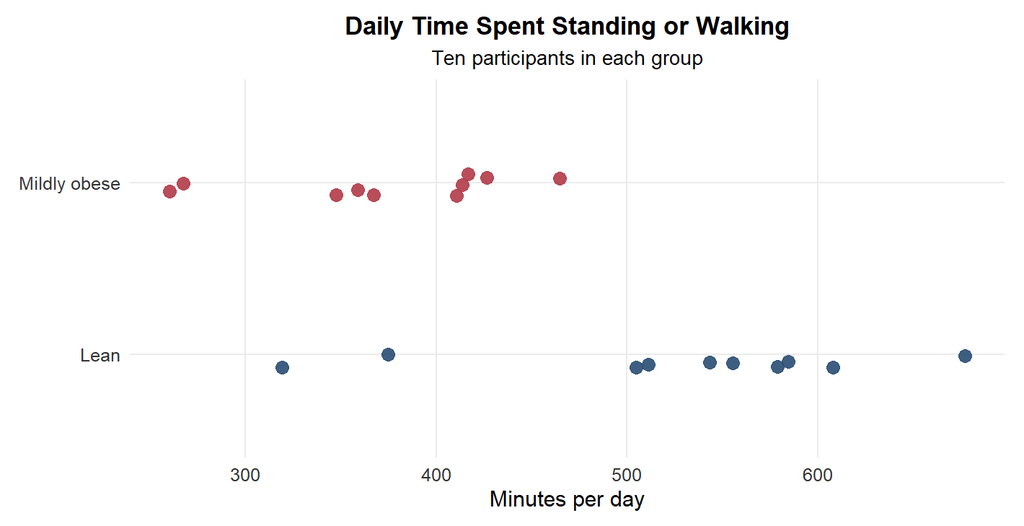

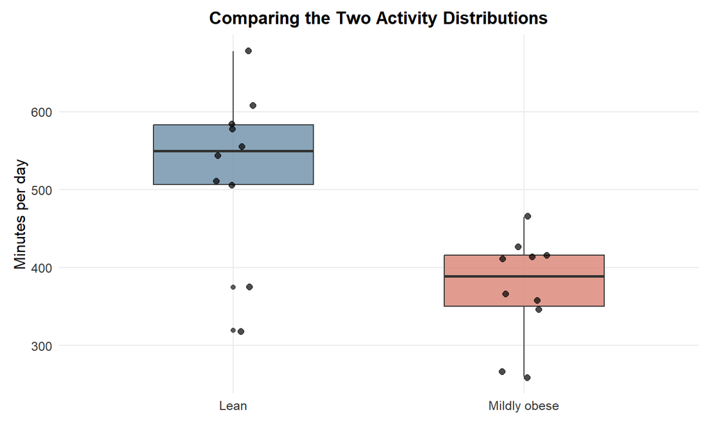

### 18.10.2 Conditions and Scope

- The two groups contain different participants and can be treated as independent.
- The samples are small, but the graphs do not show severe skewness or extreme outliers.
- The participants were volunteers rather than simple random samples.
- The results can cautiously describe similar adults, but broad population generalization requires care.
- Body type was not randomly assigned. The study is observational and cannot establish causation.

### 18.10.3 Hypotheses

The researchers suspected in advance that the lean group would spend more time standing or walking:

$$H_0:\mu_1-\mu_2=0$$

$$H_a:\mu_1-\mu_2>0$$

### 18.10.4 Sample Summaries

```r
c(
  n_lean = length(lean_activity),
  mean_lean = mean(lean_activity),
  sd_lean = sd(lean_activity),
  n_obese = length(obese_activity),
  mean_obese = mean(obese_activity),
  sd_obese = sd(obese_activity)
)
```

```
##     n_lean  mean_lean    sd_lean    n_obese mean_obese   sd_obese
##    10.0000   525.7513   107.1209    10.0000   373.2692    67.4983
```

Rounded summaries are

| Group | $n$ | $\bar{x}$ | $s$ |
| --- | --- | --- | --- |
| Lean | $10$ | $525.751$ | $107.121$ |
| Mildly obese | $10$ | $373.269$ | $67.498$ |

The estimate is

$$\bar{x}_1-\bar{x}_2
=
525.751-373.269
=
152.482$$

### 18.10.5 Standard Error

$$\operatorname{SE}
=
\sqrt{
\frac{107.121^2}{10}
+
\frac{67.498^2}{10}
}
=
\sqrt{1147.491+455.598}
\approx
40.039$$

### 18.10.6 Degrees of Freedom

$$df
=
\frac{
(1147.491+455.598)^2
}{
\dfrac{1147.491^2}{9}
+
\dfrac{455.598^2}{9}
}
\approx
15.17$$

### 18.10.7 Test Statistic

$$t
=
\frac{152.482-0}{40.039}
\approx
3.808$$

### 18.10.8 One-Sided $P$-Value

```r
t_activity <- 3.808
df_activity <- 15.17
pt(t_activity, df = df_activity, lower.tail = FALSE)
```

```
## [1] 0.0008419867
```

The $P$-value is approximately

$$P(T_{15.17}\geq3.808)
\approx
0.00084$$

If the population means were equal, a difference at least this large in the predicted direction would be very unusual.

### 18.10.9 Direct Welch Test in R

```r
t.test(
  lean_activity,
  obese_activity,
  alternative = "greater",
  var.equal = FALSE
)
```

```
##
##  Welch Two Sample t-test
##
## data:  lean_activity and obese_activity
## t = 3.8084, df = 15.174, p-value = 0.000841
## alternative hypothesis: true difference in means is greater than 0
## 95 percent confidence interval:
##  82.34506      Inf
## sample estimates:
## mean of x mean of y
##  525.7513  373.2692
```

R uses Welch’s procedure by default. The explicit argument `var.equal = FALSE` makes the choice clear.

### 18.10.10 Test Conclusion

The data provide very strong evidence that the population mean daily standing or walking time is greater for lean adults than for mildly obese adults similar to those studied.

This is evidence of an association. It is not evidence that body type causes the activity difference.

## 18.11 Example 18.4: Estimating the Activity Difference

A test addresses evidence against equal population means. A confidence interval estimates the possible size of the difference.

For $df\approx15.17$, the $95\%$ critical value is approximately

$$t^*\approx2.129$$

The margin of error is

$$m
=
2.129(40.039)
\approx
85.255$$

Therefore,

$$152.482\pm85.255
=
(67.227,\ 237.737)$$

### 18.11.1 Direct Confidence Interval in R

```r
t.test(
  lean_activity,
  obese_activity,
  alternative = "two.sided",
  conf.level = 0.95,
  var.equal = FALSE
)$conf.int
```

```
## [1]  67.22674 237.73746
## attr(,"conf.level")
## [1] 0.95
```

### 18.11.2 Interpretation

We are $95\%$ confident that lean adults similar to those studied spend, on average, between approximately $67$ and $238$ more minutes per day standing or walking than mildly obese adults similar to those studied.

The interval is wide because

- both samples contain only $10$ participants;
- activity varies substantially among individuals; and
- both sample variances contribute to the standard error.

Whether this range is biologically or clinically important requires subject-matter judgment.

## 18.12 Example 18.5: Transgenic Chickens

Researchers compared the hatching weights of $45$ transgenic chickens resistant to avian influenza and $54$ independently selected commercial chickens of the same breed.

Let Group $1$ be transgenic chickens and Group $2$ be commercial chickens.

The two-sided hypotheses are

$$H_0:\mu_1-\mu_2=0$$

$$H_a:\mu_1-\mu_2\neq0$$

The sample summaries are

| Group | $n$ | $\bar{x}$ (g) | $s$ (g) |
| --- | --- | --- | --- |
| Transgenic | $45$ | $45.14$ | $3.32$ |
| Commercial | $54$ | $44.99$ | $4.57$ |

### 18.12.1 Manual Calculation from Summaries

The estimated difference is

$$45.14-44.99=0.15\text{ g}$$

The standard error is

$$\operatorname{SE}
=
\sqrt{
\frac{3.32^2}{45}
+
\frac{4.57^2}{54}
}
\approx
0.795\text{ g}$$

The Welch degrees of freedom are approximately

$$df\approx95.3$$

The test statistic is

$$t
=
\frac{0.15}{0.795}
\approx
0.19$$

The two-sided $P$-value is approximately

$$2P(T_{95.3}\geq0.19)
\approx
0.85$$

The precise calculation from the unrounded original data gives approximately $0.847$.

### 18.12.2 R Calculation from Summary Statistics

```r
n1 <- 45
xbar1 <- 45.14
s1 <- 3.32

n2 <- 54
xbar2 <- 44.99
s2 <- 4.57

se <- sqrt(s1^2 / n1 + s2^2 / n2)

df <- (s1^2 / n1 + s2^2 / n2)^2 /
  ((s1^2 / n1)^2 / (n1 - 1) +
   (s2^2 / n2)^2 / (n2 - 1))

t_statistic <- (xbar1 - xbar2) / se
p_value <- 2 * pt(-abs(t_statistic), df = df)

c(SE = se, df = df, t = t_statistic, P_value = p_value)
```

```
##         SE         df          t    P_value
##  0.7947953 95.3317603  0.1887278  0.8507073
```

### 18.12.3 Test Conclusion

The data do not provide statistically significant evidence that the two population mean hatching weights differ.

This conclusion does not prove exact equality. The data remain compatible with a negative difference, zero difference or a positive difference.

### 18.12.4 Confidence Interval

Using the original unrounded data, the $95\%$ confidence interval for

$$\mu_{\text{transgenic}}-\mu_{\text{commercial}}$$

is approximately

$$(-1.424,\ 1.731)\text{ g}$$

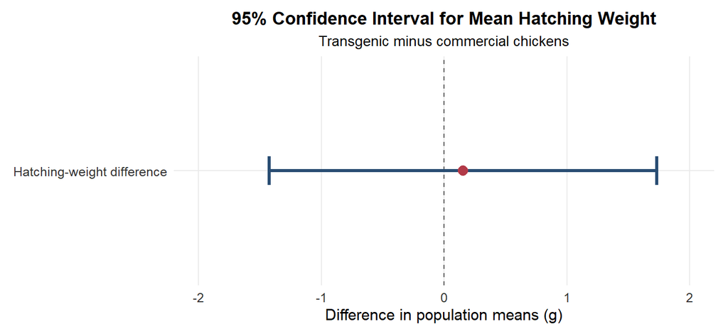

The interval includes zero and plausible differences in both directions. This agrees with failure to reject the two-sided null hypothesis at $\alpha=0.05$.

## 18.13 Statistical Significance, Effect Size and Study Design

These ideas answer different questions.

### 18.13.1 Statistical Significance

The $P$-value addresses whether the observed difference is unusual under a specified null model.

### 18.13.2 Effect Size

The point estimate and confidence interval describe the direction and plausible size of the population difference.

### 18.13.3 Generalization

Random sampling determines whether the result can be extended to a broader population.

### 18.13.4 Causation

Random assignment determines whether a treatment difference can reasonably be interpreted causally.

A small $P$-value cannot repair confounding, selection bias or poor measurement.

## 18.14 Robustness of Two-Sample $t$ Procedures

A procedure is **robust** when its confidence level or $P$-value changes little under moderate violations of its distributional conditions.

Welch procedures are often robust to moderate non-Normality, especially when both samples are reasonably large.

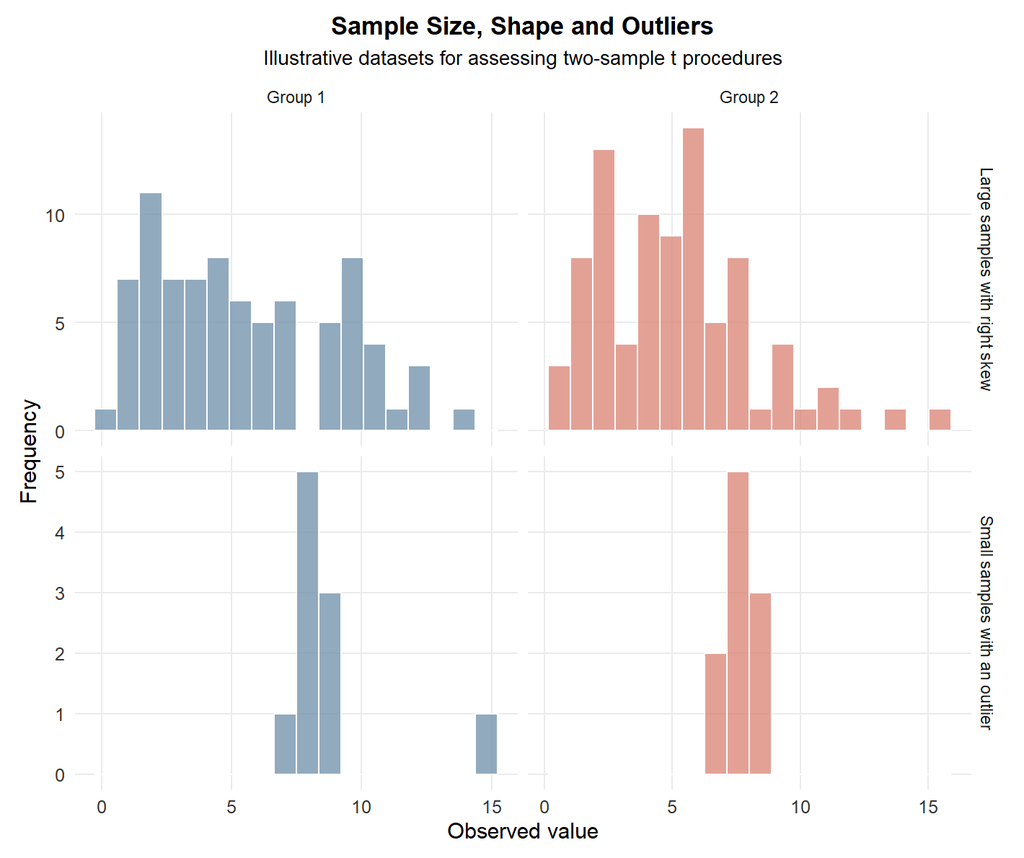

### 18.14.1 Practical Guidelines

Assess each group separately.

- **Small samples:** Both groups should be reasonably symmetric, single-peaked and free of outliers.
- **Moderate samples:** Mild skewness is usually acceptable, but strong skewness and outliers remain concerning.
- **Large samples:** Greater skewness can often be tolerated, although influential outliers should still be investigated.

A large sample in one group does not completely compensate for a very small sample in the other group.

### 18.14.2 Why Outliers Matter

Both $\bar{x}$ and $s$ are sensitive to extreme observations. An outlier can affect

- the estimated difference;
- the standard error;
- the degrees of freedom;
- the test statistic; and
- the confidence interval.

A valid unusual observation should not be removed merely because it changes statistical significance. Any exclusion must be scientifically justified and reported.

### 18.14.3 Large Samples Do Not Make Every Mean Meaningful

A calculation may be mathematically reliable while the parameter remains scientifically unhelpful.

For example, a bimodal distribution of bee cocoon widths may combine male and female cocoons. One overall mean mixes two biologically distinct groups. A more useful analysis would separate the groups.

## 18.15 Why Welch’s Procedure Is Preferred

Two versions of the two-sample $t$ procedure appear in software.

| Feature | Welch procedure | Pooled procedure |
| --- | --- | --- |
| Population variance assumption | Allows $\sigma_1^2\neq\sigma_2^2$ | Requires $\sigma_1^2=\sigma_2^2$ |
| Variance estimates | Uses $s_1^2$ and $s_2^2$ separately | Combines them into one pooled estimate |
| Degrees of freedom | Welch–Satterthwaite approximation | $n_1+n_2-2$ |
| Recommendation | Use routinely | Avoid unless equality is strongly justified |

### 18.15.1 The Pooled Variance

The pooled procedure estimates a common population variance using

$$s_p^2
=
\frac{
(n_1-1)s_1^2+(n_2-1)s_2^2
}{
n_1+n_2-2
}$$

and then uses

$$\operatorname{SE}_{\text{pooled}}
=
s_p
\sqrt{
\frac{1}{n_1}
+
\frac{1}{n_2}
}$$

The procedure is valid only under the additional equal-variance assumption.

### 18.15.2 Why Avoid Pooling

Welch’s procedure is preferred because

- equal population variances are rarely known;
- sample standard deviations that look similar do not prove equality;
- pooled inference can be inaccurate when sample sizes and variances differ; and
- Welch’s procedure performs well whether or not the variances are equal.

### 18.15.3 R Defaults to Welch

```r
# Recommended
t.test(response ~ group, data = study_data)

# The same choice written explicitly
t.test(
  response ~ group,
  data = study_data,
  var.equal = FALSE
)

# Pooled procedure
t.test(
  response ~ group,
  data = study_data,
  var.equal = TRUE
)
```

Do not change `var.equal` to `TRUE` merely because the sample standard deviations appear close.

## 18.16 Avoid Routine Inference about Standard Deviations

The procedures in this chapter compare means. They do not test whether two population standard deviations are equal.

Classical variance-ratio procedures are highly sensitive to non-Normality. Skewness and outliers can distort them substantially.

If variability is the scientific outcome of interest, the method should be selected specifically for the distribution, measurement scale and study design. An equal-variance test is not needed before applying Welch’s procedure.

## 18.17 Choosing the Correct Procedure

| Data structure | Recommended procedure |
| --- | --- |
| One quantitative sample | One-sample $t$ |
| Same individuals measured twice | Matched pairs $t$ on differences |
| Two unrelated quantitative samples | Welch two-sample $t$ |
| Two independent categorical outcomes | A procedure for proportions |
| More than two independent quantitative groups | A multiple-group method such as ANOVA |

### 18.17.1 Decision Checklist

Before using a two-sample $t$ procedure, ask:

1. Is the response quantitative?
2. Are there exactly two groups?
3. Are the observations in the two groups independent?
4. Were the samples or treatments produced using a defensible random process?
5. Do graphs show skewness, outliers or important subgroups?
6. Is the order of subtraction clearly defined?
7. Is Welch’s procedure being used?
8. Does the conclusion respect the study design?

## 18.18 Common Errors and Corrections

### 18.18.1 Treating Paired Data as Independent

**Error:** Applying a two-sample test to before-and-after observations.

**Correction:** Calculate one difference per subject and apply a one-sample $t$ procedure to those differences.

### 18.18.2 Assuming the Variances Must Be Equal

**Error:** Performing an equal-variance test before every comparison.

**Correction:** Use Welch’s procedure, which does not require equal population variances.

### 18.18.3 Losing the Order of Subtraction

**Error:** Calculating Group $1$ minus Group $2$ and interpreting the result as Group $2$ minus Group $1$.

**Correction:** Define the order in words before calculation and maintain it throughout.

### 18.18.4 Choosing the Alternative after Seeing the Data

**Error:** Using a one-sided alternative because one sample mean happened to be larger.

**Correction:** Determine the direction from the research question before examining the result.

### 18.18.5 Interpreting a Large $P$-Value as Proof of Equality

**Error:** Concluding that the two population means are identical.

**Correction:** State that the data do not provide sufficient evidence of a difference. Examine the confidence interval to see which differences remain plausible.

### 18.18.6 Interpreting a Small $P$-Value as a Large Effect

**Error:** Treating strong evidence as evidence of a large or important difference.

**Correction:** Report the estimate and confidence interval and use subject-matter knowledge to assess importance.

### 18.18.7 Claiming Causation from an Observational Study

**Error:** Attributing the mean difference to the grouping variable without random assignment.

**Correction:** Describe an association and discuss plausible confounding variables.

## 18.19 Reporting Templates

### 18.19.1 Confidence Interval

> The estimated difference in population means, defined as Group $1$ minus Group $2$, was $\bar{x}_1-\bar{x}_2$. A $C\%$ Welch confidence interval was $(L,U)$. We are $C\%$ confident that the population mean for Group $1$ is between $L$ and $U$ units above the population mean for Group $2$, subject to the sampling and model conditions.

### 18.19.2 Hypothesis Test

> A Welch two-sample $t$ test gave $t=\cdots$, $df=\cdots$ and $P=\cdots$. The data provide [little/moderate/strong] evidence that the population mean for Group $1$ is [greater than/less than/different from] the population mean for Group $2$. The conclusion applies to the population supported by the study design and does not imply causation unless treatments were randomly assigned.

## 18.20 Chapter Summary

### 18.20.1 Parameter and Estimate

$$\text{Parameter}=\mu_1-\mu_2$$

$$\text{Estimate}=\bar{x}_1-\bar{x}_2$$

### 18.20.2 Standard Error

$$\operatorname{SE}
=
\sqrt{
\frac{s_1^2}{n_1}
+
\frac{s_2^2}{n_2}
}$$

### 18.20.3 Welch Test Statistic

$$t
=
\frac{
(\bar{x}_1-\bar{x}_2)-\Delta_0
}{
\operatorname{SE}
}$$

### 18.20.4 Confidence Interval

$$(\bar{x}_1-\bar{x}_2)
\pm
t^*\operatorname{SE}$$

### 18.20.5 Main Interpretive Principles

- Inspect both samples before inference.
- Keep the group order consistent.
- Use Welch’s procedure rather than pooling.
- Report a confidence interval to describe effect size and precision.
- A large $P$-value does not prove equality.
- Statistical significance does not establish practical importance.
- The study design controls generalization and causation.

### 18.20.6 Essential R Functions

```r
mean(group1)
sd(group1)
length(group1)

t.test(group1, group2)
t.test(group1, group2, alternative = "greater")
t.test(response ~ group, data = study_data)

pt(t_value, df = degrees_of_freedom)
qt(0.975, df = degrees_of_freedom)
```

### 18.20.7 Final Workflow

1. Define both populations and the order of subtraction.
2. Confirm that the samples are independent.
3. Graph and summarize both distributions.
4. Assess randomness, independence, shape and outliers.
5. Use Welch’s standard error and degrees of freedom.
6. Calculate a test or confidence interval.
7. Interpret the result in context.
8. Separate statistical evidence from effect size, generalization and causation.